# BIOS 611 Project 3

Christina Zhou

12/1/2019

## Introduction

Urban Ministries of Durham (UMD) is a non-profit organization that serves its community by offering servies that help reduce the rate of homelessness in Durham, NC. The website for UMD is www.umdurham.org. One service UMD offers is shelter. This service is meant to provide struggling individuals or families with a safe place to stay until they are able to get on their own. In the meantime, UMD provides resources to help this happen, such as helping with finding jobs or providing professional clothes for interviews, etc.

## Data Cleaning

There is a lot of data from UMD regarding who enters and exits the shelter resource of the organization. This data identifies each individual as a client, and records one’s age, gender, ethnicity, race, entry and exit dates, and reasons for leaving UMD, as well as other data collection. For this project, we focus on any association between duration of stay at UMD and gender, race, ethnicity, and age at entry. We define duration of stay as number of nights spent at UMD, calculated from the date of entry and the date of exit. We merge the two datasets and preprocess the two datasets in python. For this project, we remove any data with missing data, since the fraction of those with any missing data is less than 1%. Thus, the full non-missing dataset has a total of 5189 observations.

## Exploratory Analysis

In the three tables below, we examine the counts per category of the three variables Ethnicity, Race, and Gender for the non-misisng dataset.

| Client.Ethnicity | Count |
| --- | --- |
| Client doesn’t know (HUD) | 8 |
| Client refused (HUD) | 8 |
| Data not collected (HUD) | 13 |
| Hispanic/Latino (HUD) | 186 |
| Non-Hispanic/Non-Latino (HUD) | 4974 |

| Client.Primary.Race | Count |
| --- | --- |
| American Indian or Alaska Native (HUD) | 84 |
| Asian (HUD) | 3 |
| Black or African American (HUD) | 3797 |
| Client doesn’t know (HUD) | 3 |
| Client refused (HUD) | 5 |
| Data not collected (HUD) | 6 |
| Native Hawaiian or Other Pacific Islander (HUD) | 10 |
| White (HUD) | 1281 |

| Client.Gender | Count |
| --- | --- |
| Female | 1260 |
| Male | 3912 |
| Trans Female (MTF or Male to Female) | 17 |

There are more males than females, and more females than transgendered females. Since the proportion of transgendered females is very low for the full dataset of non-missing data (about 0.33%), we removed transgendered female observations from our analysis. Likewise, from the full dataset of non-missing data, approximately 0.56% of clients either don’t know or refuse to provide their ethnicity, or data was not collected for client ethnicity. Thus, since this is extremely low as well, we dropped these subjects from the analysis. Similar to the above categories, only 0.27% of clients either don’t know or refuse to provide their primary race, or data was not collected for primary race. Thus, we remove these clients from the final analysis as well.

Lastly, from the table above for Primary Race, we see that the highest (by far) proportion of clients are Black or African American, with White being the next largest race. Thus, since the rest of the races are less prevalent, we combine these races into the category “other”, to compare clients entering UMD of the race Black or African American vs. Other races.

Below is the distribution of our outcome of interest, total nights spent at UMD.

```
##    Min. 1st Qu.  Median    Mean 3rd Qu.    Max.
##    0.00    5.00   16.00   39.72   45.00  894.00
```

We note that the maximum number of total nights spent at UMD is 894 days. This is a major outlier. We use the interquartile range rule to eliminate outliers. The IQR is $Q3-Q1 = 45-5 =$ 40. The IQR states that any values below $Q1 - 1.5*IQR$ or above $Q3 + 1.5*IQR$ are likely outliers. Thus, we omit any observations with total nights values below -55 or above 105.

Thus, our final dataset has a total of 4601 observations. In the section below, we look at different plots of the exploratory variables (age at entry, gender, ethnicity, and race) to get an idea of how the final data set looks.

From the plots and tables below, we can see that the age with the most number of clients is around 50. There are more people aged 50 and below than above 50. Additionally, for this final client dataset, there are more Black or African Americans than any other race. There are more males than females and more non-Hispanic/non-Latino ethnicities than Hispanic/Latino ethnicities.

```
##  Client.Age.at.Entry  Total.Nights
##  Min.   :18.00       Min.   :  0.00
##  1st Qu.:34.00       1st Qu.:  5.00
##  Median :46.00       Median : 13.00
##  Mean   :43.77       Mean   : 22.17
##  3rd Qu.:53.00       3rd Qu.: 31.00
##  Max.   :81.00       Max.   :105.00
```

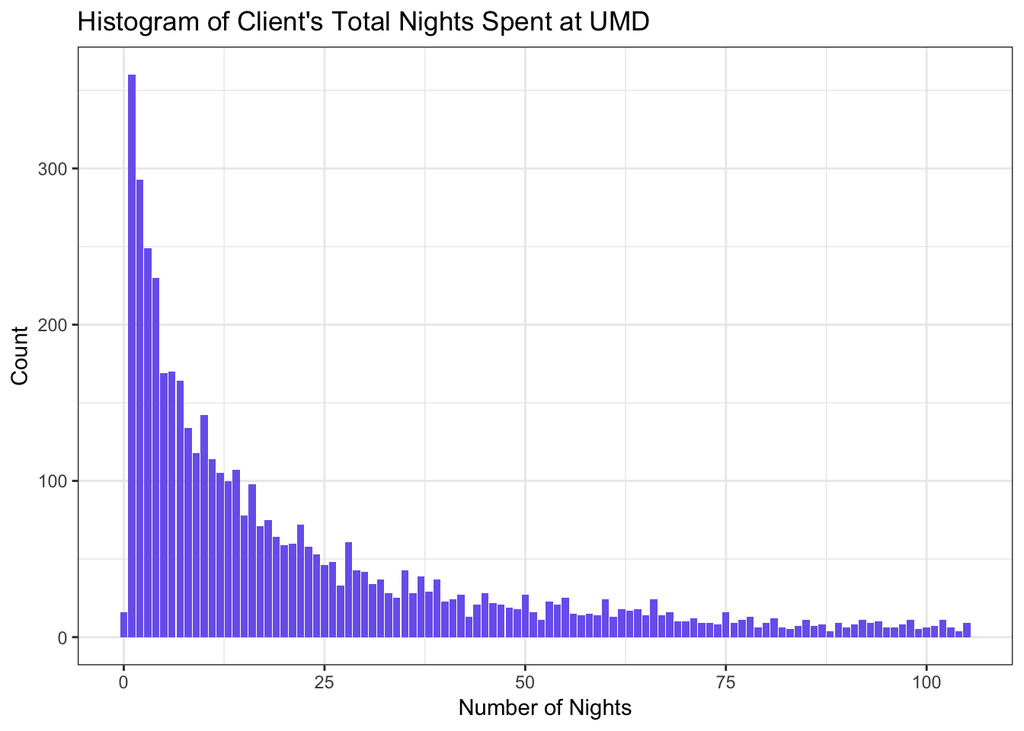

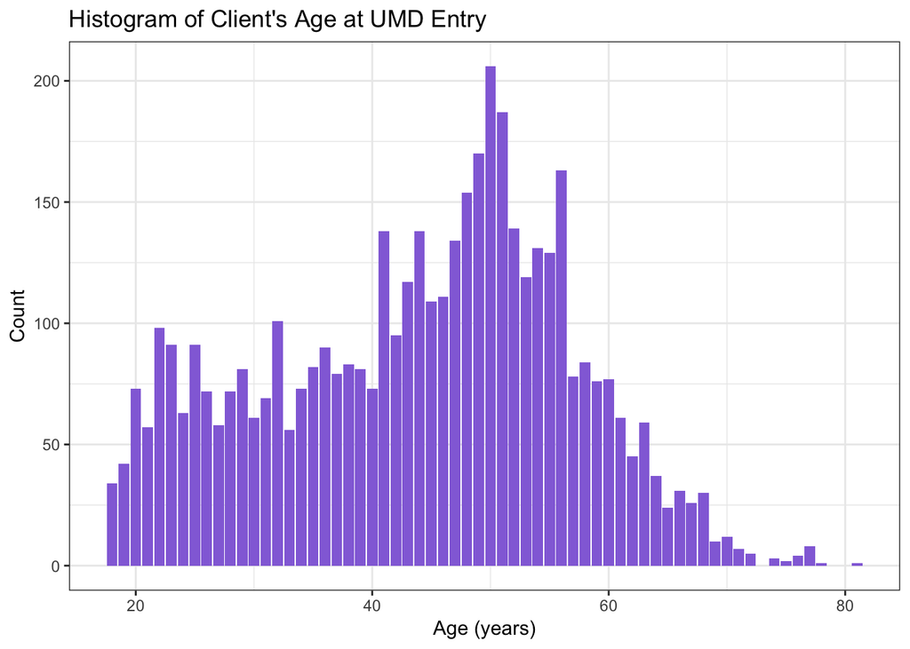

| Var1 | Freq |
| --- | --- |
| Black or African American (HUD) | 3362 |
| Other | 1239 |

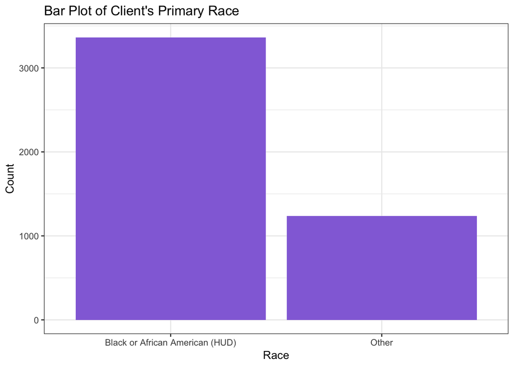

| Var1 | Freq |
| --- | --- |
| Female | 1102 |
| Male | 3499 |

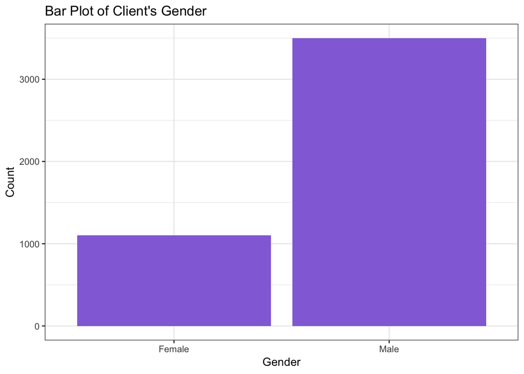

| Var1 | Freq |
| --- | --- |
| Hispanic/Latino (HUD) | 167 |
| Non-Hispanic/Non-Latino (HUD) | 4434 |

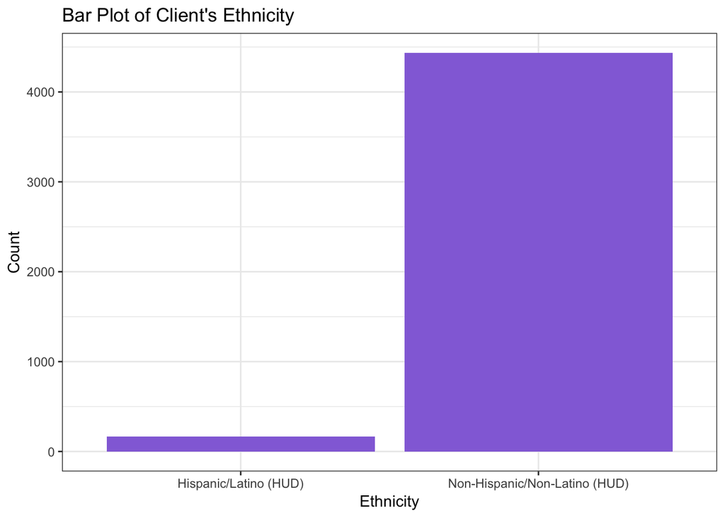

## Analysis

We want to examine associations between our outcome of interest, total nights of staying at UMD, and demographic variables age in years at entry, gender, race, and ethnicity. Since our outcome is total nights spent at UMD, it is count data. We first fit a univariate poisson regression model for age.

```
##
## Call:
## glm(formula = Total.Nights ~ Client.Age.at.Entry, family = poisson,
##     data = dat)
##
## Deviance Residuals:
##    Min      1Q  Median      3Q     Max
## -6.925  -4.532  -2.160   1.826  13.291
##
## Coefficients:
##                      Estimate Std. Error z value Pr(>|z|)
## (Intercept)         2.9339066  0.0113749  257.93   <2e-16 ***
## Client.Age.at.Entry 0.0037403  0.0002464   15.18   <2e-16 ***
## ---
## Signif. codes:  0 '***' 0.001 '**' 0.01 '*' 0.05 '.' 0.1 ' ' 1
##
## (Dispersion parameter for poisson family taken to be 1)
##
##     Null deviance: 103177  on 4600  degrees of freedom
## Residual deviance: 102946  on 4599  degrees of freedom
## AIC: 122735
##
## Number of Fisher Scoring iterations: 5
```

However, the residual deviance (102946) was much larger than the degrees of freedom (4599); therefore, we choose to fit a generalized linear model with log-link and robust variance instead.

We thus fit a generalized linear model with log-link with robust variance. To do this, we first conduct univariate analysis by fitting four separate models to analyze the association between UMD stay duration and each of our covariates individually. These models are summarized below. This shows us the unadjusted crude association between UMD count of nights spent at UMD and each covariate. The indiviudal models for age at entry, gender (reference = female), and ethnicity (reference = Hispanic/Latino) show significant effects of these factors on UMD stay duration. The race effect (reference = Black or African American) is not statistically significant.

```
##
## Call:
## glm(formula = Total.Nights ~ Client.Age.at.Entry, family = poisson(link = "log"),
##     data = dat)
##
## Deviance Residuals:
##    Min      1Q  Median      3Q     Max
## -6.925  -4.532  -2.160   1.826  13.291
##
## Coefficients:
##                      Estimate Std. Error z value Pr(>|z|)
## (Intercept)         2.9339066  0.0113749  257.93   <2e-16 ***
## Client.Age.at.Entry 0.0037403  0.0002464   15.18   <2e-16 ***
## ---
## Signif. codes:  0 '***' 0.001 '**' 0.01 '*' 0.05 '.' 0.1 ' ' 1
##
## (Dispersion parameter for poisson family taken to be 1)
##
##     Null deviance: 103177  on 4600  degrees of freedom
## Residual deviance: 102946  on 4599  degrees of freedom
## AIC: 122735
##
## Number of Fisher Scoring iterations: 5
```

```
##
## Call:
## glm(formula = Total.Nights ~ Client.Gender, family = poisson(link = "log"),
##     data = dat)
##
## Deviance Residuals:
##    Min      1Q  Median      3Q     Max
## -7.014  -4.625  -2.219   1.750  12.914
##
## Coefficients:
##                    Estimate Std. Error z value Pr(>|z|)
## (Intercept)        3.202592   0.006074  527.26   <2e-16 ***
## Client.GenderMale -0.138888   0.007088  -19.59   <2e-16 ***
## ---
## Signif. codes:  0 '***' 0.001 '**' 0.01 '*' 0.05 '.' 0.1 ' ' 1
##
## (Dispersion parameter for poisson family taken to be 1)
##
##     Null deviance: 103177  on 4600  degrees of freedom
## Residual deviance: 102801  on 4599  degrees of freedom
## AIC: 122590
##
## Number of Fisher Scoring iterations: 5
```

```
##
## Call:
## glm(formula = Total.Nights ~ Client.Ethnicity, family = poisson(link = "log"),
##     data = dat)
##
## Deviance Residuals:
##    Min      1Q  Median      3Q     Max
## -6.684  -4.439  -2.145   1.730  13.216
##
## Coefficients:
##                                               Estimate Std. Error z value
## (Intercept)                                    2.87461    0.01838  156.37
## Client.EthnicityNon-Hispanic/Non-Latino (HUD)  0.23169    0.01866   12.42
##                                               Pr(>|z|)
## (Intercept)                                     <2e-16 ***
## Client.EthnicityNon-Hispanic/Non-Latino (HUD)   <2e-16 ***
## ---
## Signif. codes:  0 '***' 0.001 '**' 0.01 '*' 0.05 '.' 0.1 ' ' 1
##
## (Dispersion parameter for poisson family taken to be 1)
##
##     Null deviance: 103177  on 4600  degrees of freedom
## Residual deviance: 103011  on 4599  degrees of freedom
## AIC: 122800
##
## Number of Fisher Scoring iterations: 5
```

```
##
## Call:
## glm(formula = Total.Nights ~ Client.Primary.Race, family = poisson(link = "log"),
##     data = dat)
##
## Deviance Residuals:
##    Min      1Q  Median      3Q     Max
## -6.665  -4.418  -2.109   1.771  12.691
##
## Coefficients:
##                          Estimate Std. Error z value Pr(>|z|)
## (Intercept)              3.098048   0.003664 845.518   <2e-16 ***
## Client.Primary.RaceOther 0.002669   0.007054   0.378    0.705
## ---
## Signif. codes:  0 '***' 0.001 '**' 0.01 '*' 0.05 '.' 0.1 ' ' 1
##
## (Dispersion parameter for poisson family taken to be 1)
##
##     Null deviance: 103177  on 4600  degrees of freedom
## Residual deviance: 103177  on 4599  degrees of freedom
## AIC: 122966
##
## Number of Fisher Scoring iterations: 5
```

Next, we look at the joint effects of these factors by fitting a multivariable GLM. The results show that race is not statistically significant. Removing this variable from the model and fitting another model with just age, gender, and ethnicity, we can see that all the variables are statistically significant. Note that the magnitude of the effects in the multivariable model are similar to the univariate analysis result effects. This indicates that the other variables in the model did not explain the association between the UMD nights spent and each variable of interest; thus it appears that the effects of the variables on UMD nights are independent of each other. Thus we can conclude that age at entry, gender, and ethnicity are independently associated with UMD duration of stay.

```
##
## Call:
## glm(formula = Total.Nights ~ Client.Gender + Client.Age.at.Entry +
##     Client.Ethnicity + Client.Primary.Race, family = poisson(link = "log"),
##     data = dat)
##
## Deviance Residuals:
##    Min      1Q  Median      3Q     Max
## -7.101  -4.492  -2.167   1.807  13.562
##
## Coefficients:
##                                                 Estimate Std. Error
## (Intercept)                                    2.8079779  0.0228461
## Client.GenderMale                             -0.1447679  0.0071626
## Client.Age.at.Entry                            0.0041440  0.0002468
## Client.EthnicityNon-Hispanic/Non-Latino (HUD)  0.2204345  0.0191521
## Client.Primary.RaceOther                       0.0114810  0.0072667
##                                               z value Pr(>|z|)
## (Intercept)                                    122.91   <2e-16 ***
## Client.GenderMale                              -20.21   <2e-16 ***
## Client.Age.at.Entry                             16.79   <2e-16 ***
## Client.EthnicityNon-Hispanic/Non-Latino (HUD)   11.51   <2e-16 ***
## Client.Primary.RaceOther                         1.58    0.114
## ---
## Signif. codes:  0 '***' 0.001 '**' 0.01 '*' 0.05 '.' 0.1 ' ' 1
##
## (Dispersion parameter for poisson family taken to be 1)
##
##     Null deviance: 103177  on 4600  degrees of freedom
## Residual deviance: 102370  on 4596  degrees of freedom
## AIC: 122165
##
## Number of Fisher Scoring iterations: 5
```

```
##
## Call:
## glm(formula = Total.Nights ~ Client.Gender + Client.Age.at.Entry +
##     Client.Ethnicity, family = poisson(link = "log"), data = dat)
##
## Deviance Residuals:
##    Min      1Q  Median      3Q     Max
## -7.114  -4.489  -2.156   1.808  13.546
##
## Coefficients:
##                                                 Estimate Std. Error
## (Intercept)                                    2.8183681  0.0218718
## Client.GenderMale                             -0.1459618  0.0071228
## Client.Age.at.Entry                            0.0041462  0.0002468
## Client.EthnicityNon-Hispanic/Non-Latino (HUD)  0.2137140  0.0186740
##                                               z value Pr(>|z|)
## (Intercept)                                    128.86   <2e-16 ***
## Client.GenderMale                              -20.49   <2e-16 ***
## Client.Age.at.Entry                             16.80   <2e-16 ***
## Client.EthnicityNon-Hispanic/Non-Latino (HUD)   11.44   <2e-16 ***
## ---
## Signif. codes:  0 '***' 0.001 '**' 0.01 '*' 0.05 '.' 0.1 ' ' 1
##
## (Dispersion parameter for poisson family taken to be 1)
##
##     Null deviance: 103177  on 4600  degrees of freedom
## Residual deviance: 102373  on 4597  degrees of freedom
## AIC: 122165
##
## Number of Fisher Scoring iterations: 5
```

## Conclusions

In conclusion, most people who visited UMD were Black or African American, Male, and non-Hispanic/non-Latino. There are more people aged 50 and below, than above 50. From our model analysis, we saw that gender, age at entry, and ethnicity were all associated with UMD nights spent. However, race was not statistically significant associated with nights spent at UMD.